# Assignment - 2

#### 2. What is a choice of k that balances between over fitting and ignoring the predictor information, k is taken as 3.

```r
# Calculating the accuracy level for the values of k
# Setting the range of k values to take into consideration
Edu_G <- data.frame(k = seq(1, 15, 1), overallaccuracy = rep(0, 15))
for(i in 1:15) {
  knn.prediction_1 <- class::knn(train = training_datanorm,
                                 test = validation_datanorm,
                                 cl = training_data_frame$Personal.Loan, k = i)
  Edu_G[i, 2] <- confusionMatrix(knn.prediction_1, as.factor(validation_data_frame$Personal.Loan), positive =
                                   "1")$overall[1]
  }


which(Edu_G[,2] == max(Edu_G[,2]))
```

```
## [1] 3
```

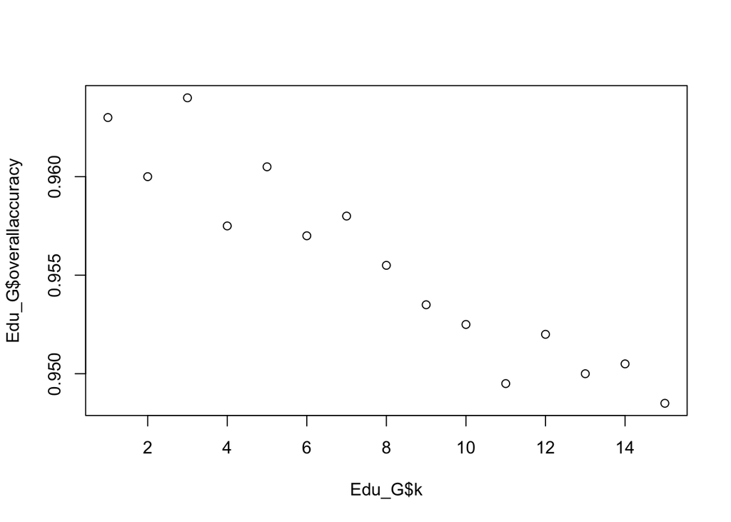

```r
plot(Edu_G$k,Edu_G$overallaccuracy)
```

#### 3.confusion matrix for the validation data that results from using the best k.

```r
knn.prediction_2 <- class::knn(train = training_datanorm,
                        test = validation_datanorm,
                        cl = training_data_frame$Personal.Loan, k = 3)
confusionMatrix(knn.prediction_2,as.factor(validation_data_frame$Personal.Loan))
```

```
## Confusion Matrix and Statistics
##
##           Reference
## Prediction    0    1
##          0 1786   63
##          1    9  142
##
##                Accuracy : 0.964
##                  95% CI : (0.9549, 0.9717)
##     No Information Rate : 0.8975
##     P-Value [Acc > NIR] : < 2.2e-16
##
##                   Kappa : 0.7785
##
##  Mcnemar's Test P-Value : 4.208e-10
##
##             Sensitivity : 0.9950
##             Specificity : 0.6927
##          Pos Pred Value : 0.9659
##          Neg Pred Value : 0.9404
##              Prevalence : 0.8975
##          Detection Rate : 0.8930
##    Detection Prevalence : 0.9245
##       Balanced Accuracy : 0.8438
##
##        'Positive' Class : 0
##
```

4. Consider the following customer: Age = 40, Experience = 10, Income = 84, Family = 2, CCAvg = 2, Education_1 = 0, Education_2 = 1, Education_3 = 0, Mortgage = 0, Securities Account = 0, CD Account = 0, Online = 1 and Credit Card = 1. Classify the customer using the best k.

```r
# Classifying the customer using the best K, K result taken from query 2 after finding the K ie 3.
customer_new = data.frame(Age = 40,
                           Experience = 10,
                           Income = 84,
                           Family = 2,
                           CCAvg = 2,
                           Education.1 = 0,
                           Education.2 = 1,
                           Education.3 = 0,
                           Mortgage = 0,
                           Securities.Account = 0,
                           CD.Account = 0,
                           Online = 1,
                           CreditCard = 1)

knn.prediction_3 <- class::knn(train = training_datanorm,
                         test = customer_new,
                         cl = training_data_frame$Personal.Loan, k = 3)
knn.prediction_3
```

```
## [1] 1
## Levels: 0 1
```

```r
#The customer has been classified as approved for personal loan
```

5.Repartition the data, this time into training, validation, and test sets (50% : 30% : 20%). Apply the k-NN method with the k chosen above. Compare the confusion matrix of the test set with that of the training and validation sets. Comment on the differences and their reason.

```r
set.seed(2)
# Removing 50% of the modified data
training.set_2 = sample(row.names(Universal_Bank_latest_data),0.5*dim(Universal_Bank_latest_data)[1])
#Take 30% of the data from the remaining 50% as Validation Data
validation.set2 = sample(setdiff(row.names(Universal_Bank_latest_data), training.set_2), 0.3*dim(Universal_Bank_latest_data)[1])
#Take remaining 20% of the modified data as Test Data
testing.set_2 = setdiff(row.names(Universal_Bank_latest_data),union(training.set_2,validation.set2))

training.norm_data_frame_2 = Universal_Bank_latest_data[training.set_2,]
validation.norm.data_frame_2 = Universal_Bank_latest_data[validation.set2,]
testing.norm.data_frame_2 = Universal_Bank_latest_data[testing.set_2,]

# Transposing the data
t(t(names(training.norm_data_frame_2)))
```

```
##       [,1]
##  [1,] "Age"
##  [2,] "Experience"
##  [3,] "Income"
##  [4,] "Family"
##  [5,] "CCAvg"
##  [6,] "Education.1"
##  [7,] "Education.2"
##  [8,] "Education.3"
##  [9,] "Mortgage"
## [10,] "Personal.Loan"
## [11,] "Securities.Account"
## [12,] "CD.Account"
## [13,] "Online"
## [14,] "CreditCard"
```

```r
# Applying k-NN method with the chosen K.

training_knn2 = knn(train = training.norm_data_frame_2[,-8], test = training.norm_data_frame_2[,-8], cl = training.norm_data_frame_2[,8], k=3)

validation_knn2 = knn(train = training.norm_data_frame_2[,-8], test = validation.norm.data_frame_2[,-8], cl = training.norm_data_frame_2[,8], k=3)

testing_knn2 = knn(train = training.norm_data_frame_2[,-8], test = testing.norm.data_frame_2[,-8], cl = training.norm_data_frame_2[,8], k=3)
```